# Credit risk EDA

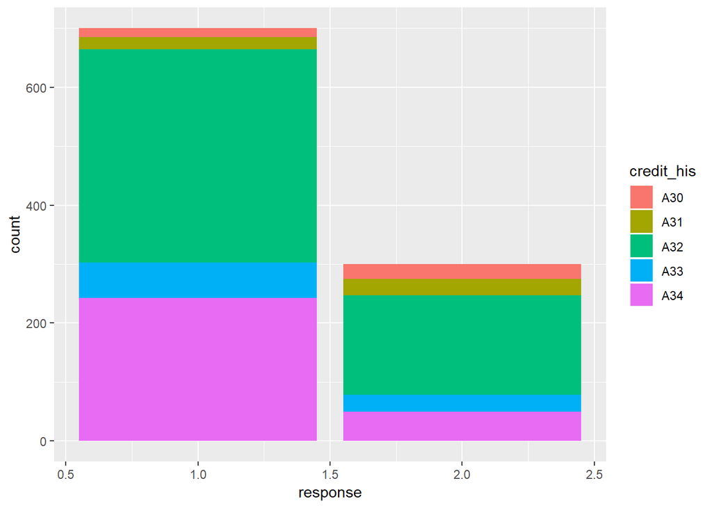

```r
german_credit%>%
ggplot(aes(response, fill=credit_his))+geom_bar()
```

Credit history  
A30 : no credits taken/ all credits paid back duly  
A31 : all credits at this bank paid back duly  
A32 : existing credits paid back duly till now  
A33 : delay in paying off in the past  
A34 : critical account/ other credits existing (not at this bank)

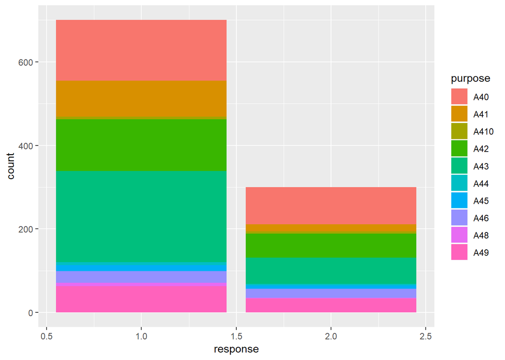

```r
german_credit%>%
ggplot(aes(response, fill=purpose))+geom_bar()
```

Purpose A40 : car (new) A41 : car (used) A42 : furniture/equipment A43 : radio/television A44 : domestic appliances A45 : repairs A46 : education A47 : (vacation - does not exist?) A48 : retraining A49 : business A410 : others

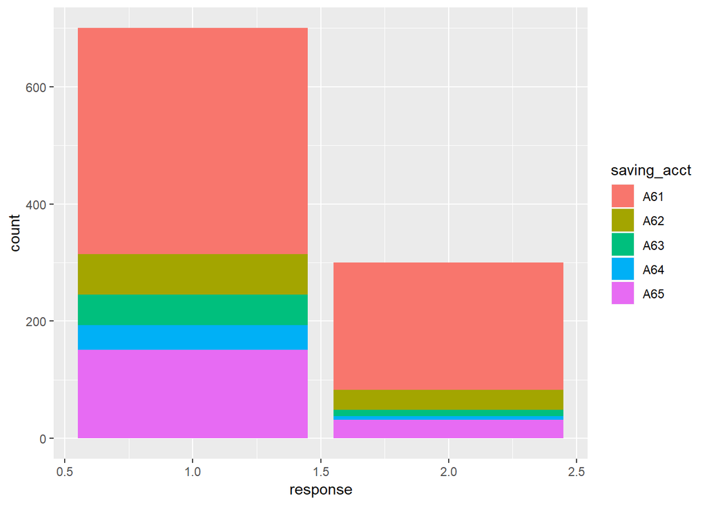

```r
german_credit%>%
ggplot(aes(response, fill=saving_acct))+geom_bar()
```

Savings account/bonds A61 : … < 100 DM A62 : 100 <= … < 500 DM A63 : 500 <= … < 1000 DM A64 : .. >= 1000 DM A65 : unknown/ no savings account

```r
(nrow(filter(german_credit, present_emp == 'A71' & response == 2))/nrow(filter(german_credit,response == 2 )))*100
```

```
## [1] 7.666667
```

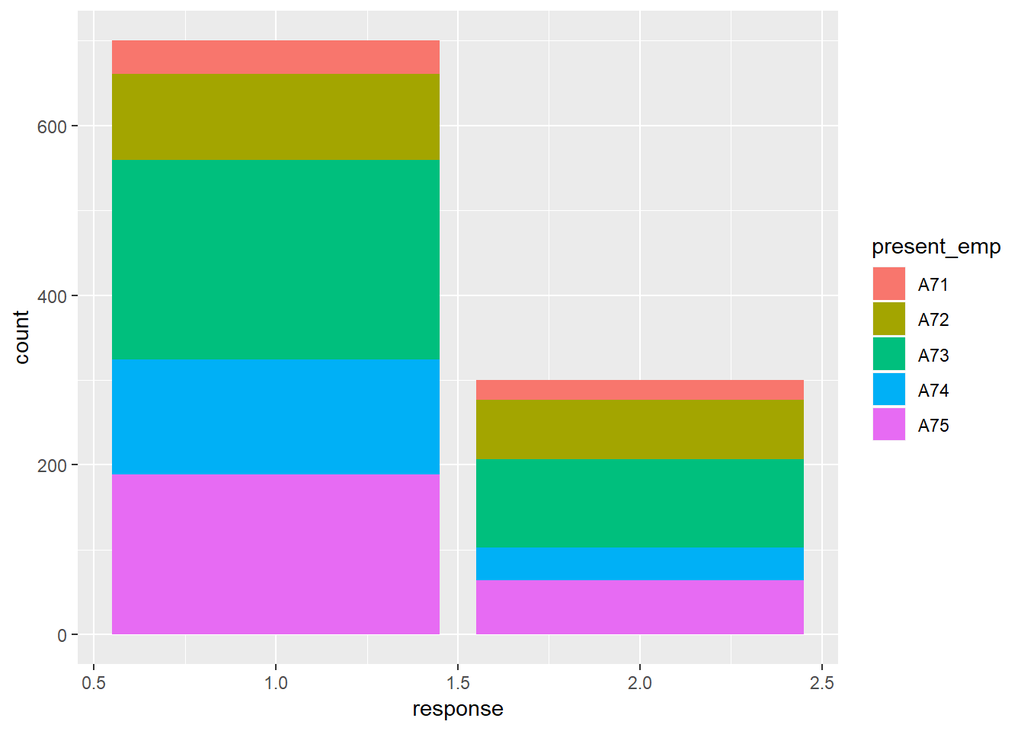

```r
german_credit%>%
ggplot(aes(response, fill=present_emp))+geom_bar()
```

Present employment since A71 : unemployed A72 : … < 1 year A73 : 1 <= … < 4 years A74 : 4 <= … < 7 years A75 : .. >= 7 years

```r
(nrow(filter(german_credit, sex == 'A93' & response == 2))/nrow(filter(german_credit,response == 2 )))*100
```

```
## [1] 48.66667
```

```r
(nrow(filter(german_credit, sex == 'A93' & response == 1))/nrow(filter(german_credit,response == 1 )))*100
```

```
## [1] 57.42857
```

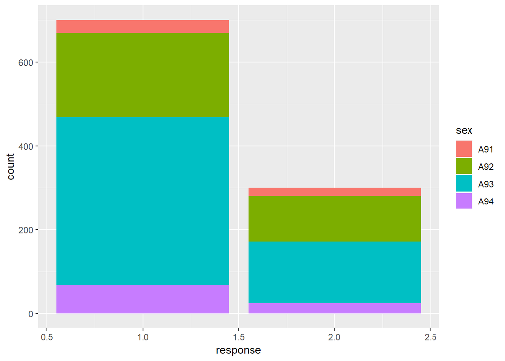

```r
german_credit%>%
ggplot(aes(response, fill=sex))+geom_bar()
```

Personal status and sex A91 : male : divorced/separated A92 : female : divorced/separated/married A93 : male : single A94 : male : married/widowed A95 : female : single

```r
(nrow(filter(german_credit, other_debtor == 'A101' & response == 2))/nrow(filter(german_credit,response == 2 )))*100
```

```
## [1] 90.66667
```

```r
(nrow(filter(german_credit, other_debtor == 'A101' & response == 1))/nrow(filter(german_credit,response == 1 )))*100
```

```
## [1] 90.71429
```

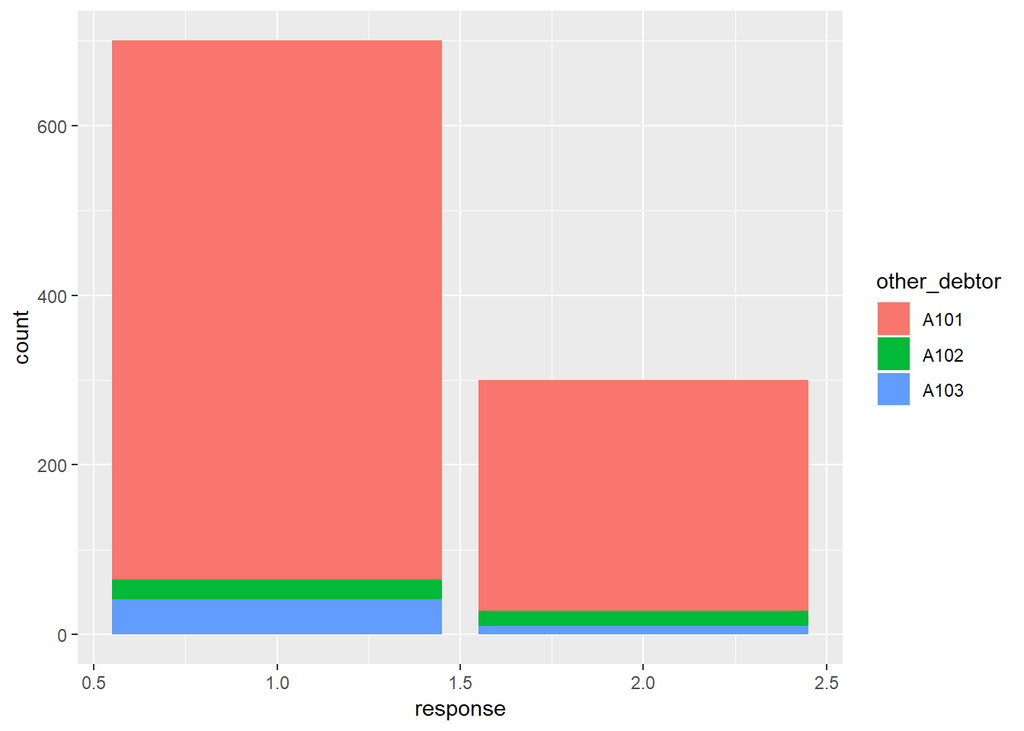

```r
german_credit%>%
ggplot(aes(response, fill=other_debtor))+geom_bar()
```

Other debtors / guarantors A101 : none A102 : co-applicant A103 : guarantor

```r
(nrow(filter(german_credit, property == 'A121' & response == 1))/nrow(filter(german_credit,response == 1 )))*100
```

```
## [1] 31.71429
```

```r
(nrow(filter(german_credit, property == 'A123' & response == 1))/nrow(filter(german_credit,response == 1 )))*100
```

```
## [1] 32.85714
```

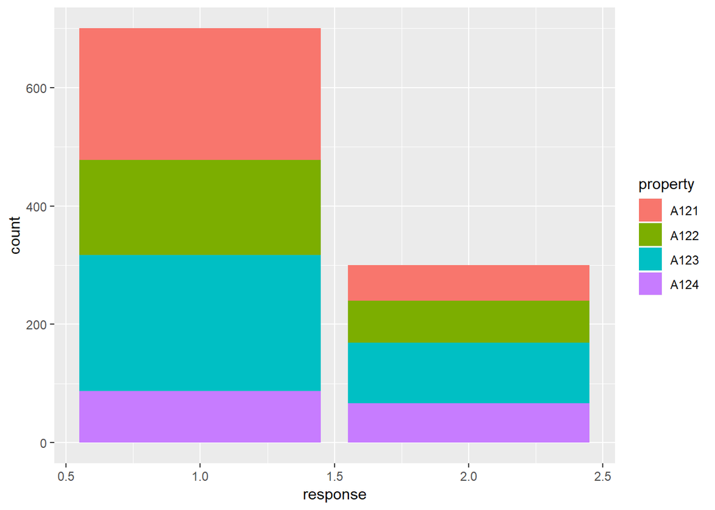

```r
german_credit%>%
ggplot(aes(response, fill=property))+geom_bar()
```

A121 : real estate A122 : if not A121 : building society savings agreement/ life insurance A123 : if not A121/A122 : car or other, not in attribute 6 A124 : unknown / no property

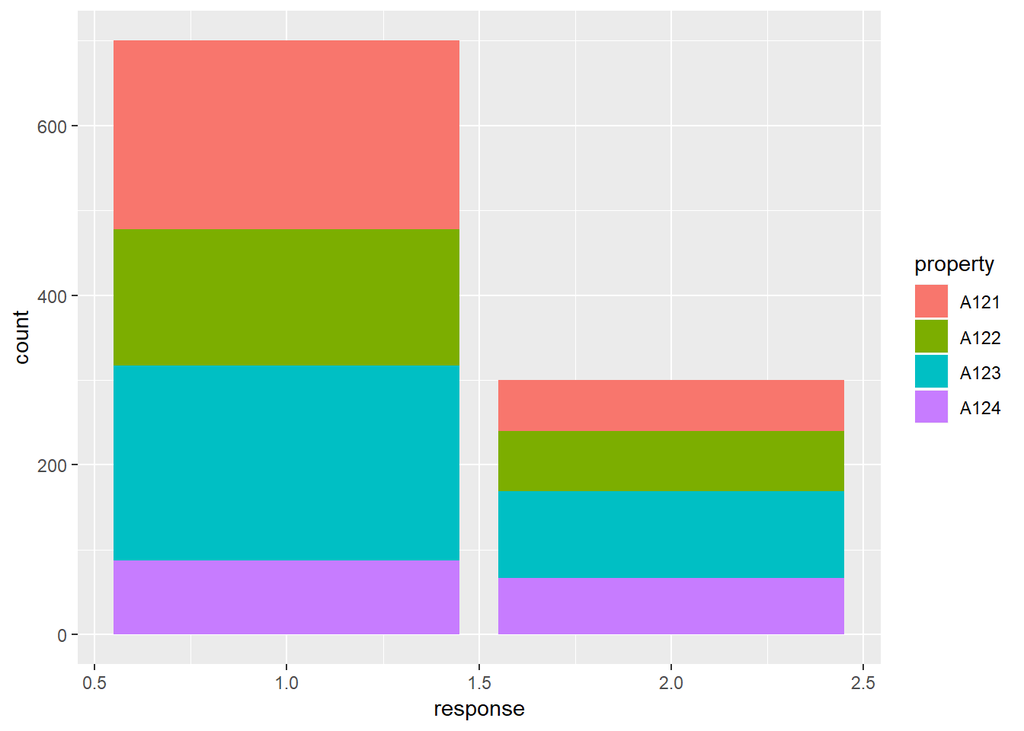

```r
german_credit%>%
ggplot(aes(response, fill=property))+geom_bar()
```

```r
(nrow(filter(german_credit, other_install == 'A143' & response == 2))/nrow(filter(german_credit,response == 2 )))*100
```

```
## [1] 74.66667
```

```r
(nrow(filter(german_credit, other_install == 'A143' & response == 1))/nrow(filter(german_credit,response == 1 )))*100
```

```
## [1] 84.28571
```

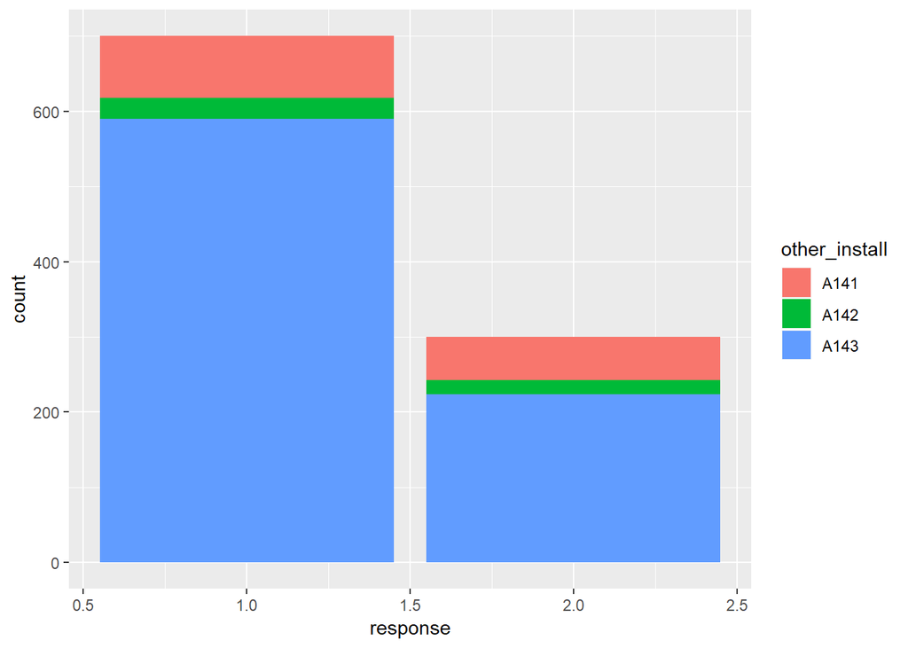

```r
german_credit%>%
ggplot(aes(response, fill=other_install))+geom_bar()
```

Other installment plans A141 : bank A142 : stores A143 : none

```r
(nrow(filter(german_credit, housing == 'A152' & response == 2))/nrow(filter(german_credit,response == 2 )))*100
```

```
## [1] 62
```

```r
(nrow(filter(german_credit, housing == 'A152' & response == 1))/nrow(filter(german_credit,response == 1 )))*100
```

```
## [1] 75.28571
```

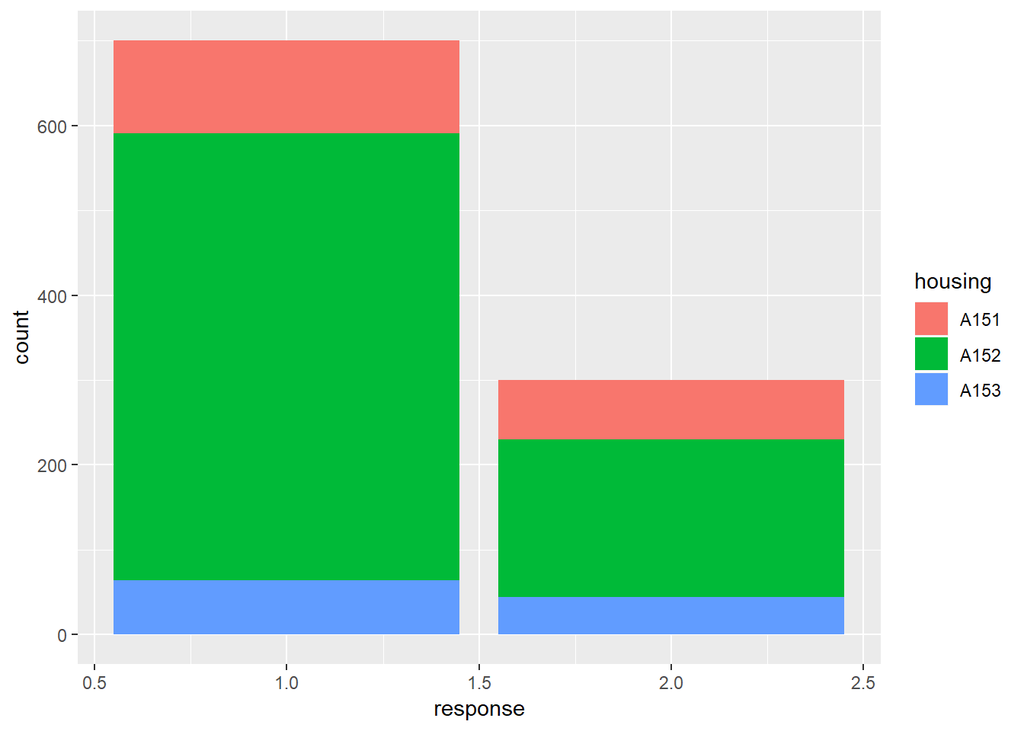

```r
german_credit%>%
ggplot(aes(response, fill=housing))+geom_bar()
```

Housing A151 : rent A152 : own A153 : for free

```r
(nrow(filter(german_credit, job == 'A173' & response == 2))/nrow(filter(german_credit,response == 2 )))*100
```

```
## [1] 62
```

```r
(nrow(filter(german_credit, job == 'A173' & response == 1))/nrow(filter(german_credit,response == 1 )))*100
```

```
## [1] 63.42857
```

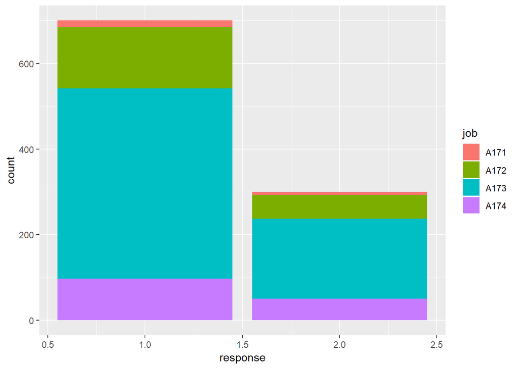

```r
german_credit%>%
ggplot(aes(response, fill=job))+geom_bar()
```

Job A171 : unemployed/ unskilled - non-resident A172 : unskilled - resident A173 : skilled employee / official A174 : management/ self-employed/ highly qualified employee/ officer

```r
(nrow(filter(german_credit, foreign == 'A201' & response == 2))/nrow(filter(german_credit,response == 2 )))*100
```

```
## [1] 98.66667
```

```r
(nrow(filter(german_credit, foreign == 'A201' & response == 1))/nrow(filter(german_credit,response == 1 )))*100
```

```
## [1] 95.28571
```

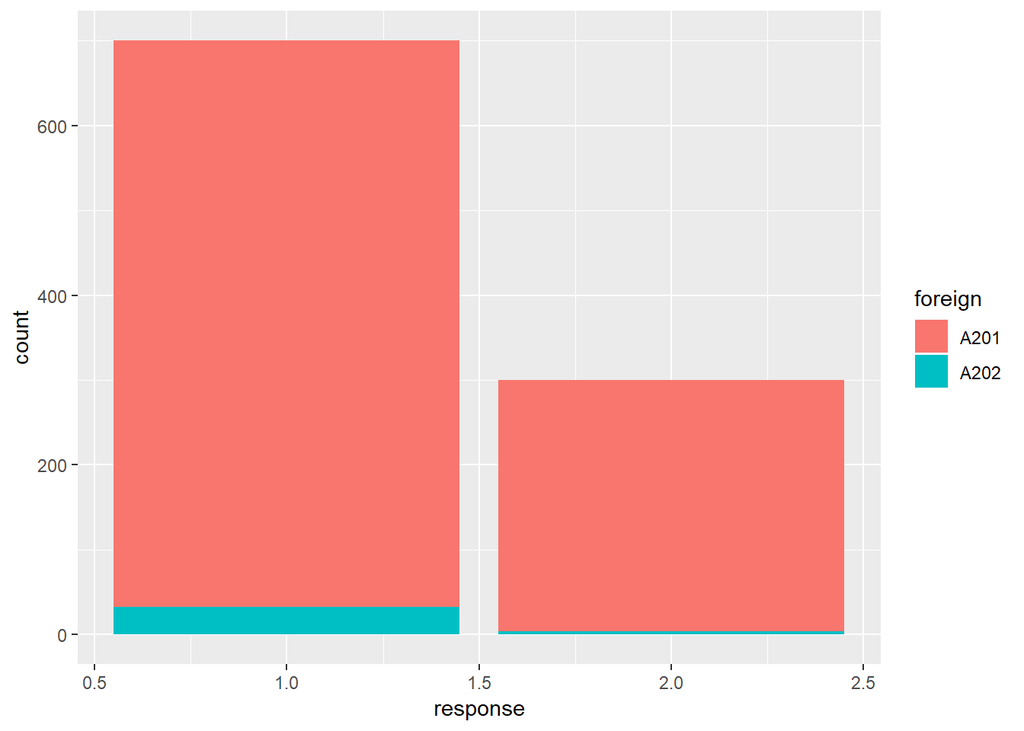

```r
german_credit%>%
ggplot(aes(response, fill=foreign))+geom_bar()
```

foreign worker A201 : yes A202 : no

```r
(nrow(filter(german_credit,  response == 2))/nrow(german_credit))*100
```

```
## [1] 30
```

```r
(nrow(filter(german_credit,  response == 1))/nrow(german_credit))*100
```

```
## [1] 70
```

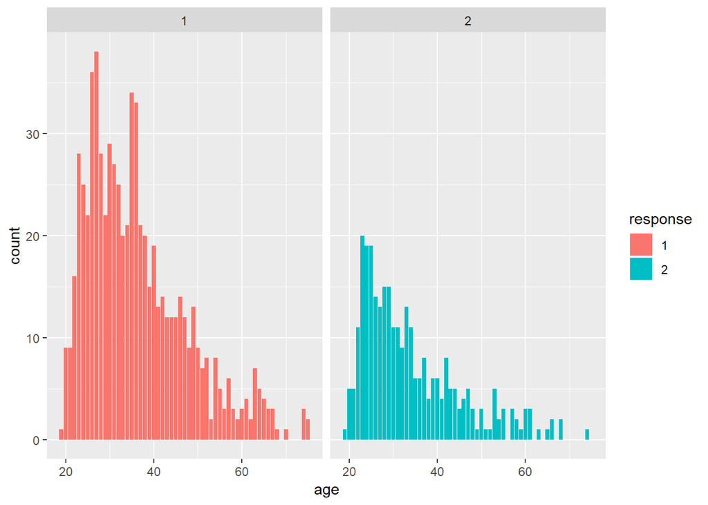

```r
german_credit$response <- as.factor(german_credit$response)
german_credit%>%
ggplot(aes(age))+geom_bar(aes(fill=response))+facet_wrap(~response)
```

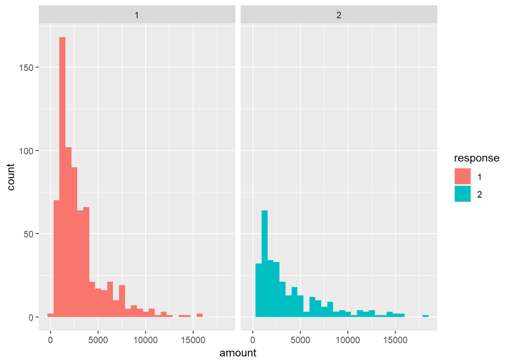

```r
german_credit%>%
ggplot(aes(amount))+geom_histogram(aes(fill=response))+facet_wrap(~response)
```